# chapt4

Christopher Huong

2024-02-19

# 4E1. In the model definition below, which line is the likelihood?

The first line. The second and third line are the prior distributions of the parameters defining the likelihood function

# 4E2. In the model definition just above, how many parameters are in the posterior distribution?

Two- mu and sigma

# 4E3. Using the model definition above, write down the appropriate form of Bayes’ theorem that includes the proper likelihood and priors.

P(A|B) = P(B|A)*P(A) / P(B)

P(mu, sigma | y) = ( P(y | mu, sigma) * P(mu) * p(sigma) ) / normalizing constant

# 4E4. In the model definition below, which line is the linear model?

mu ~ a + b * x

# 4E5. In the model definition just above, how many parameters are in the posterior distribution?

Three- alpha, beta, sigma (these are stochastic/defined by a random probability distribution)

# 4M1. For the model definition below, simulate observed y values from the prior (not the posterior).

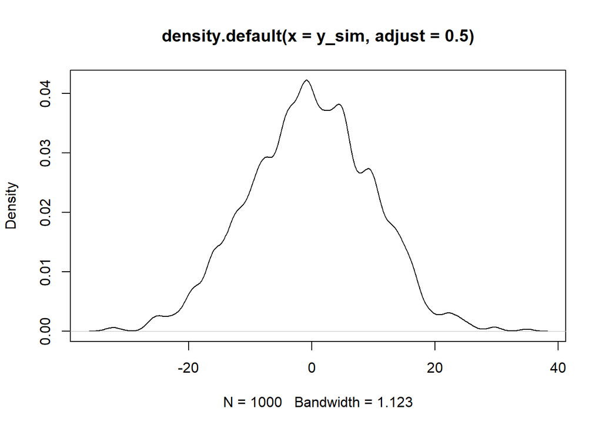

```r
mu_prior <- rnorm(1000, mean=0, sd=10) #1000 samples from a gaussian distribution with mean=0, sd=10
sigma_prior <- rexp(1000, rate=1) #1000 samples from an exponential distribution with rate=1

y_sim <- rnorm(1000, mu_prior, sigma_prior) # 1000 samples from gaussian distribution with means from mu_prior sample and sd's from sigma_prior sample

plot(density(y_sim, adjust=.5))
```

***

# 4M2. Translate the model just above into a quap formula.

lm1 <- quap( alist( y ~ dnorm(mu, sigma), mu ~ dnorm(0, 10), sigma ~ dexp(1) ), data=data )

# 4M3. Translate the quap model formula below into a mathematical model definition

yi ~ N(mu, sigma)  
mu = a + b * xi  
a ~ N(0, 10)  
b ~ Unif(0, 1)  
sigma ~ Exp(1)

# 4M4. A sample of students is measured for height each year for 3 years. After the third year, you want to fit a linear regression predicting height using year as a predictor. Write down the mathematical model definition for this regression, using any variable names and priors you choose. Be prepared to defend your choice of priors.

height ~ N(mu, sigma)  
mu = a + b * year  
a ~ N(170, 20)  
b ~ Log-N(0, 1)  
sigma ~ Exp(1)

# 4M5. Now suppose I remind you that every student got taller each year. Does this information lead you to change your choice of priors? How?

No because I already incorporated a positive relationship between height and year using a log-normal prior for b

# 4M6. Now suppose I tell you that the variance among heights for students of the same age is never more than 64cm. How does this lead you to revise your priors?

Standard deviation will range from 0 to 8

update to: sigma ~ Uniform(0,8)

# 4M7. Refit model m4.3 from the chapter, but omit the mean weight xbar this time. Compare the new model’s posterior to that of the original model. In particular, look at the covariance among the parameters. What is different? Then compare the posterior predictions of both models

```r
library(rethinking)
data("Howell1")
d <- Howell1[Howell1$age >=18, ]

xbar <- mean(d$weight)

m4.3 <- quap(
  alist(
    height ~ dnorm(mu, sigma),   #likelihood function
    mu <- a + b * (weight-xbar), #linear model
    a ~ dnorm(178, 20),          #a prior
    b ~ dlnorm(0, 1),            #b prior
    sigma ~ dunif(0, 50)         # sigma prior
  ),
  data = d)
```

Omit xbar and refit

```r
m4.3_refit <- quap(
     alist(
       height ~ dnorm(mu, sigma),   #likelihood function
       mu <- a + b * (weight), #linear model
       a ~ dnorm(178, 20),          #a prior
        b ~ dlnorm(0, 1),            #b prior
        sigma ~ dunif(0, 50)         # sigma prior
      ),
      data = d)
```

Compare posteriors

```r
precis(m4.3)
```

```
##              mean         sd        5.5%      94.5%
## a     154.6013678 0.27030764 154.1693640 155.033372
## b       0.9032809 0.04192363   0.8362789   0.970283
## sigma   5.0718805 0.19115474   4.7663783   5.377383
```

```r
precis(m4.3_refit)
```

```
##             mean         sd        5.5%       94.5%
## a     114.534181 1.89774838 111.5012128 117.5671497
## b       0.890733 0.04175801   0.8239956   0.9574704
## sigma   5.072722 0.19124924   4.7670689   5.3783753
```

Lower posterior distribution mean for alpha  
When subtracting xbar, beta becomes 0 at xbar, and alpha becomes the mean height

```r
vcov(m4.3) |> cov2cor() |> round(2)
```

```
##       a b sigma
## a     1 0     0
## b     0 1     0
## sigma 0 0     1
```

```r
vcov(m4.3_refit) |> cov2cor() |> round(2)
```

```
##           a     b sigma
## a      1.00 -0.99  0.03
## b     -0.99  1.00 -0.03
## sigma  0.03 -0.03  1.00
```

a and b are inversely correlated. This is because subtracting xbar mean-centered stuff

# 4M8. In the chapter, we used 15 knots with the cherry blossom spline. Increase the number of knots and observe what happens to the resulting spline. Then adjust also the width of the prior on the weights—change the standard deviation of the prior and watch what happens. What do you think the combination of knot number and the prior on the weights controls?

```r
library(splines)
rm(list=ls())
data("cherry_blossoms")
d <- cherry_blossoms[complete.cases(cherry_blossoms$doy),]
```

Set number of knots to 30 and get basis functions

```r
knots=30
knot_list <- quantile(d$year, probs=seq(0,1, length.out=knots))

B <- bs(d$year,
        knots=knot_list[-c(1,knots)],
        degree=3, intercept=T)
```

Get parameter weights for each basis function

```r
bspline30 <- quap(
       alist(
         D ~ dnorm(mu, sigma),
         mu <- a + B %*% w,
         a ~ dnorm(100,10),
          w ~ dnorm(0,10),
          sigma ~ dexp(1)),
       data=list(D=d$doy, B=B),
       start=list(w=rep(0, ncol(B))))
```

Plot posterior predictions

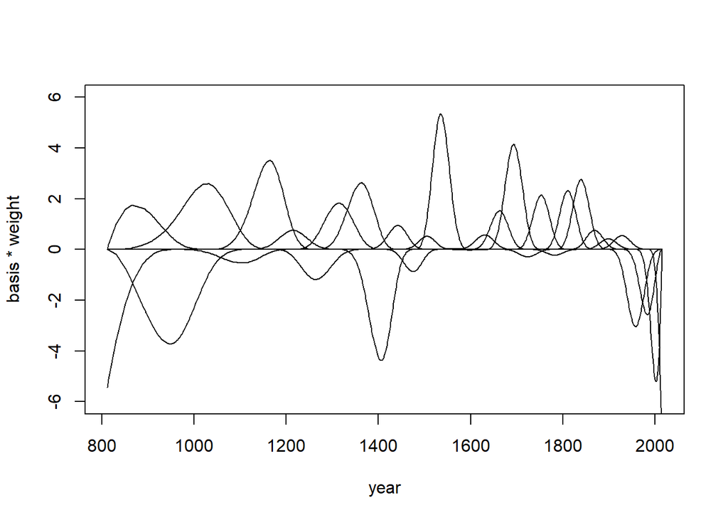

```r
post <- extract.samples(bspline30)
w <- apply(post$w, 2, mean)
plot(NULL, xlim=range(d$year), ylim=c(-6,6),
     xlab="year", ylab="basis * weight")
for (i in 1:ncol(B)) lines(d$year, w[i]*B[,i])
```

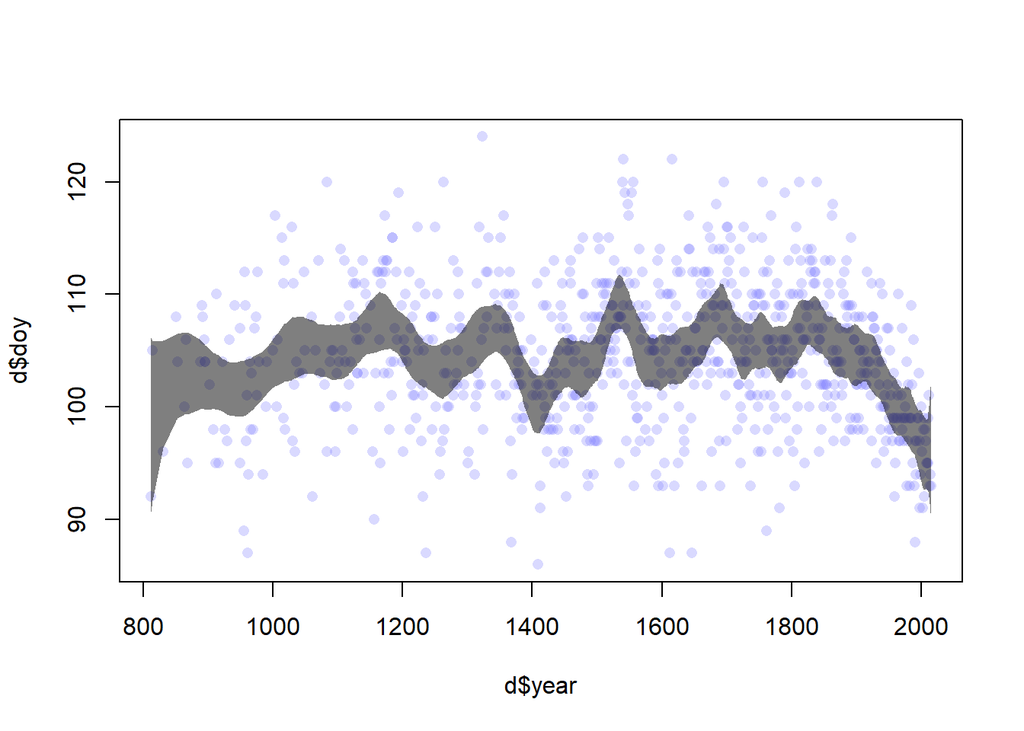

```r
#97% posterior interval for mu at each year
mu <- link(bspline30)
mu_PI <- apply(mu,2,PI,0.97)
plot(d$year, d$doy, col=col.alpha(rangi2,0.3),pch=16)
shade(mu_PI, d$year, col=col.alpha("black",0.5))
```

Very wiggly

Now, adjust width of prior on weights to sigma ~ dunif(0,50)

```r
bspline30_adjust <- quap(
       alist(
         D ~ dnorm(mu, sigma),
         mu <- a + B %*% w,
         a ~ dnorm(100,10),
          w ~ dnorm(0,10),
          sigma ~ dunif(0,50)),
       data=list(D=d$doy, B=B),
       start=list(w=rep(0, ncol(B))))
```

Plot posterior predictions

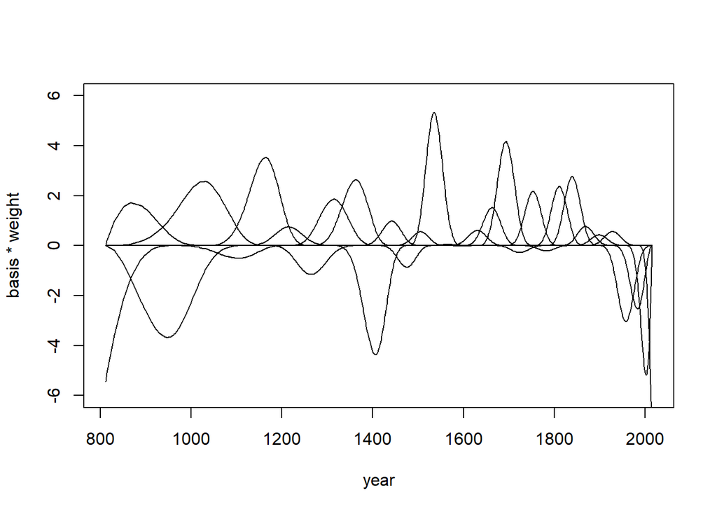

```r
post <- extract.samples(bspline30_adjust)
w <- apply(post$w, 2, mean)
plot(NULL, xlim=range(d$year), ylim=c(-6,6),
     xlab="year", ylab="basis * weight")
for (i in 1:ncol(B)) lines(d$year, w[i]*B[,i])
```

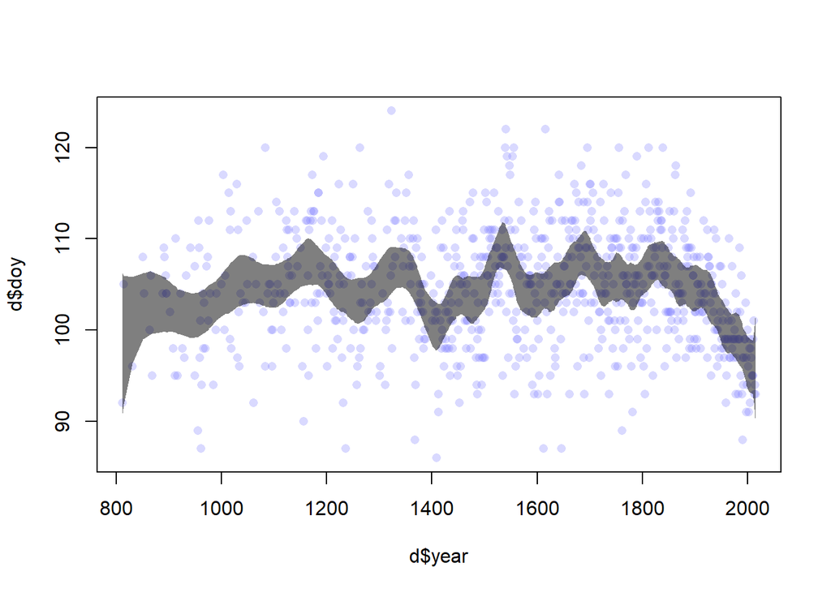

```r
#97% posterior interval for mu at each year
mu <- link(bspline30_adjust)
mu_PI <- apply(mu,2,PI,0.97)
plot(d$year, d$doy, col=col.alpha(rangi2,0.3),pch=16)
shade(mu_PI, d$year, col=col.alpha("black",0.5))
```

Not sure what changed

# 4H1. The weights listed below were recorded in the !Kung census, but heights were not recorded for these individuals. Provide predicted heights and 89% intervals for each of these individuals. That is, fill in the table below, using model-based predictions.

```r
rm(list=ls())
data("Howell1")
d <- Howell1[Howell1$age >= 18, ]

xbar <- mean(d$weight)
```

Quadratic approximation of the posterior to a linear model

```r
lm1 <- quap(
  alist(
    height ~ dnorm(mu, sigma),
    mu <- a + b * (weight-xbar),
    a ~ dnorm(170,20),
    b ~ dlnorm(0, 1),
    sigma ~ dexp(1)
  ), data=d
)
```

Extract samples from the quadratic approximation of the posterior distribution

```r
posterior <- extract.samples(lm1)
```

```r
w1 <- rnorm(1e4, posterior$a + posterior$b*(46.95-xbar), posterior$sigma)
w2 <- rnorm(1e4, posterior$a + posterior$b*(43.72-xbar), posterior$sigma)
w3 <- rnorm(1e4, posterior$a + posterior$b*(64.78-xbar), posterior$sigma)
w4 <- rnorm(1e4, posterior$a + posterior$b*(32.59-xbar), posterior$sigma)
w5 <- rnorm(1e4, posterior$a + posterior$b*(54.63-xbar), posterior$sigma)
```

Calculate expected height (mean) for each, and 89% credibility interval

```r
means <- function(w){
  return(c(mean(w), PI(w, prob=0.89)))
         }
weights <- c(w1, w2, w3, w4, w5)
expected_heights <- sapply(list(w1, w2, w3, w4, w5), means)
```

Means, and 89% CI for each 5 observed weights

```r
print(expected_heights)
```

```
##         [,1]     [,2]     [,3]     [,4]     [,5]
##     156.3020 153.4174 172.4867 143.3641 163.3670
## 5%  148.2570 145.3279 164.3549 135.3047 155.3660
## 94% 164.4127 161.4893 180.6667 151.5375 171.3175
```

# 4H2. Select out all the rows in the Howell1 data with ages below 18 years of age. If you do it right, you should end up with a new data frame with 192 rows in it. (a) Fit a linear regression to these data, using quap. Present and interpret the estimates. For every 10 units of increase in weight, how much taller does the model predict a child gets? (b) Plot the raw data, with height on the vertical axis and weight on the horizontal axis. Superimpose the MAP regression line and 89% interval for the mean. Also superimpose the 89% interval for predicted heights. (c) What aspects of the model fit concern you? Describe the kinds of assumptions you would change, if any, to improve the model. You don’t have to write any new code. Just explain what the model appears to be doing a bad job of, and what you hypothesize would be a better model.

```r
rm(list=ls())
data(Howell1)
d <- Howell1[Howell1$age < 18,]
```

1. Fit a linear regression

```r
xbar <- mean(d$weight)

lm2 <- quap(
  alist(height ~ dnorm(mu, sigma),
        mu <- a + b * (weight-xbar),
        a ~ dnorm(170,20),
        b ~ dlnorm(0,1),
        sigma ~ dexp(1)),
  data=d
)

posterior <- extract.samples(lm2)
precis(lm2)
```

```
##             mean         sd       5.5%      94.5%
## a     108.369149 0.59611720 107.416439 109.321860
## b       2.716944 0.06690762   2.610013   2.823875
## sigma   8.263426 0.40887145   7.609970   8.916881
```

2. Plot raw data, superimpose MAP regression line and 89% interval

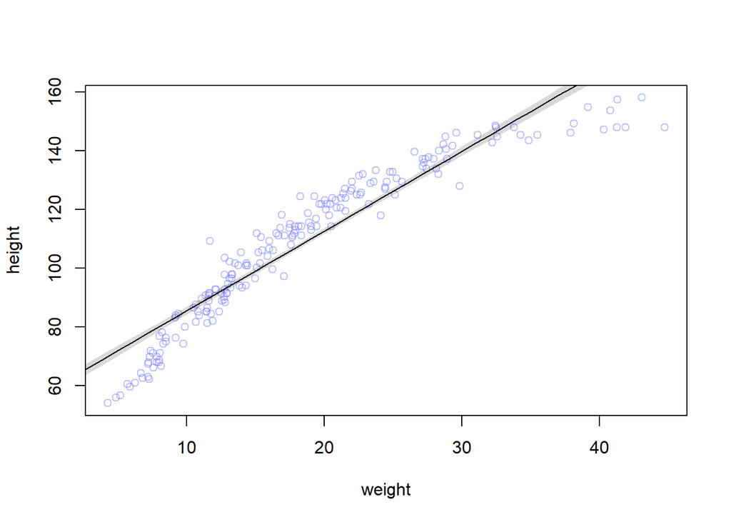

```r
#compute predicted mu heights for each weight using the posterior
mu.link <- function(weight) posterior$a + posterior$b*(weight-xbar)
weight.seq <- seq(from=1, to=50, by=1)
mu <- sapply(weight.seq, mu.link)

mu.mean <- apply(mu, 2, mean)
mu.pi <- apply(mu, 2, PI, prob=0.89)

plot(height ~ weight, data=d, col=col.alpha(rangi2, 0.5))
lines(weight.seq, mu.mean)
shade(mu.pi, weight.seq)
```

(C) Model overestimates at low and high weights, and underestimates at middle weights. A curved line would fit the data better

# 4H3. Suppose a colleague of yours, who works on allometry, glances at the practice problems just above. Your colleague exclaims, “That’s silly. Everyone knows that it’s only the logarithm of body weight that scales with height!” Let’s take your colleague’s advice and see what happens. (a) Model the relationship between height (cm) and the natural logarithm of weight (log-kg). Use the entire Howell1 data frame, all 544 rows, adults and non-adults. Can you interpret the resulting estimates?

```r
rm(list=ls())
data("Howell1")
d<- Howell1

logxbar <- mean(log(d$weight))

lm_log <- quap(
  alist(height ~ dnorm(mu, sigma),
        mu <- a + b * (log(weight)-logxbar),
        a ~ dnorm(170, 20),
        b ~ dlnorm(0,1),
        sigma ~ dexp(1)),
  data=d
)

precis(lm_log)
```

```
##             mean        sd       5.5%      94.5%
## a     138.267405 0.2191092 137.917226 138.617584
## b      47.071268 0.3808465  46.462601  47.679934
## sigma   5.110765 0.1538630   4.864863   5.356668
```

Slope is in log units. So every increase in 1 log-kg predicts a 47 cm increase in height.

# (b) Begin with this plot: plot( height ~ weight , data=Howell1 ). Then use samples from the quadratic approximate posterior of the model in (a) to superimpose on the plot: (1) the predicted mean height as a function of weight, (2) the 97% interval for the mean, and (3) the 97% interval for predicted heights

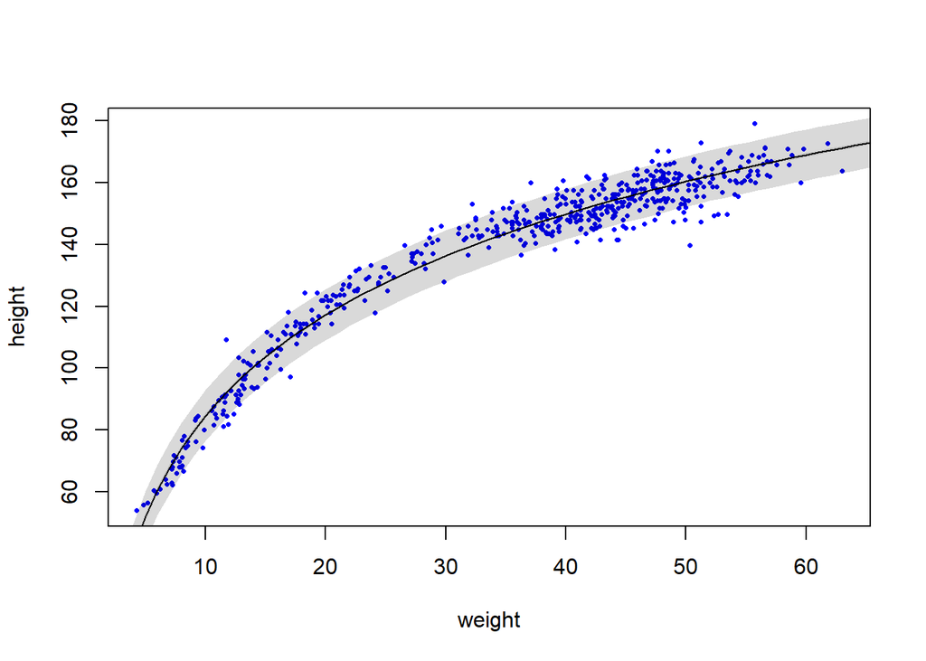

```r
posterior <- extract.samples(lm_log)
mu.link <- function(weight) posterior$a + posterior$b*(log(weight)-logxbar)
weight.seq <- seq(from=1, to=70, by=1)
mu <- sapply(weight.seq, mu.link)
mu.mean <- apply(mu, 2, mean)
mu.pi <- apply(mu, 2, PI, prob=0.89)
#89% interval for predicted heights
p.heights <- sapply(weight.seq, function(a) (rnorm(1e4, posterior$a + posterior$b * (log(a)-logxbar), posterior$sigma) |> PI(prob=0.89)))


plot(height ~ weight, data=d, col="blue", pch=16, cex=0.5)
lines(weight.seq, mu.mean)
shade(mu.pi, weight.seq)
shade(p.heights, weight.seq)
```